# Assignment 3: Machine Learning

## Section 1.3

Now we plot the ROC curve for Section 1.2.

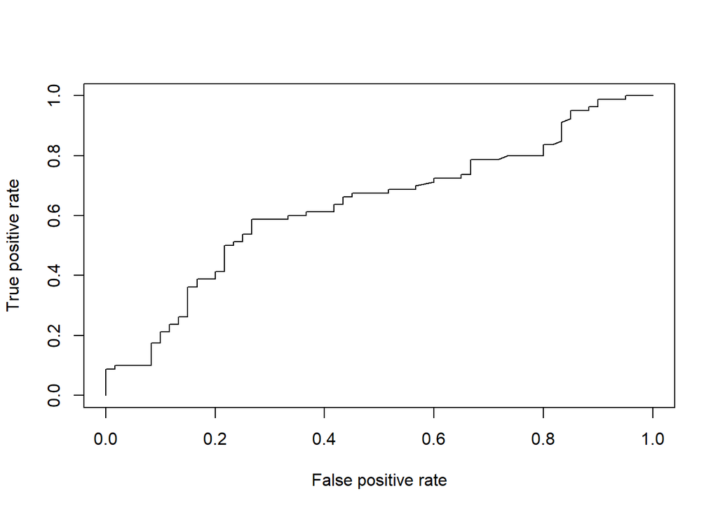

```r
rocr_pred = prediction(probability_cross_validated_data, features$isLetter)

rocr_performance <- performance(rocr_pred, "tpr", "fpr")

plot(rocr_performance)
```

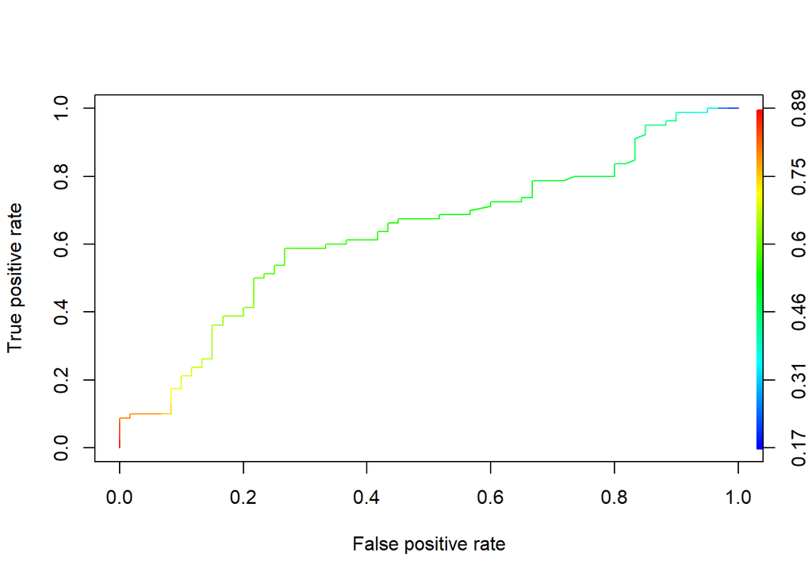

```r
plot(rocr_performance, colorize = TRUE)
```

This is a decent classifier, not perfect. It has chance level specificty and sensitivity but it’s not completely straight and with high false positive rate, the true positive rate increases as well.

At threshold, we will not collect any poor case however we ill correctly label good care cases. At the end, we will catch all poor care cases and incorrectly label all good care cases as poor cases.

However since the line is not straight, we can say that our model is not a random classifier. It is a decent classifier but not perfect

# Section 2

We first set the working directory and the source code.

```r
setwd("C:/Users/Asus/Desktop/AI Assignment")

source("./section2_code.r")
```

We first install the library to use knn model and then we import the data as features

```r
library(class)

features <-  read.csv(file = './40280938_features.csv', header = TRUE)
```

Now, we only choose a, j and no_letters as per the assignment’s specification. We know that a letters are till 1st to 8th row, j from 73rd to 80th and non-letters from 81st to 140th row.

```r
a_letters <- features[1:8,]
j_letters <- features[73:80,]
all_non_letters <- features[81:140,]
```

Once done above, we add all the above data in a separate new dataframe. This will be used throughout the second section.

```r
new_features <- rbind(a_letters, j_letters, all_non_letters)
```

Since we’ll be using ‘label’ for KNN classification, we make ‘label’ column as a categorical factor. a’ and ‘j’ are classified as ‘letter’ while ‘sad’, ‘smiley’ and ‘xclaim’ are classified separetly for four-way classification.

```r
levels = c("a","j", "sad", "smiley", "xclaim")

labels = c("letter","letter","sad", "smiley", "xclaim" )


new_features$label <- factor(new_features$label,
                        levels = levels, labels = labels)


str(new_features)
```

```
## 'data.frame':    76 obs. of  18 variables:
##  $ label          : Factor w/ 4 levels "letter","sad",..: 1 1 1 1 1 1 1 1 1 1 ...
##  $ index          : int  1 2 3 4 5 6 7 8 1 2 ...
##  $ nr_pix         : int  27 28 25 32 31 38 32 26 17 15 ...
##  $ rows_with_1    : int  0 0 0 1 0 1 0 2 8 8 ...
##  $ cols_with_1    : int  1 0 1 0 2 2 1 0 0 1 ...
##  $ rows_with_3p   : int  7 8 6 8 6 10 9 7 2 1 ...
##  $ cols_with_3p   : int  5 6 6 6 4 6 6 3 2 2 ...
##  $ aspect_ratio   : num  1.14 1.29 1.29 0.9 1.25 ...
##  $ neigh_1        : int  0 0 1 1 1 1 0 2 3 2 ...
##  $ no_neigh_above : int  5 4 4 4 8 6 5 5 4 3 ...
##  $ no_neigh_below : int  5 4 6 6 9 6 7 4 5 4 ...
##  $ no_neigh_left  : int  8 7 7 14 6 10 10 8 7 12 ...
##  $ no_neigh_right : int  8 8 7 12 7 11 8 10 9 12 ...
##  $ no_neigh_horiz : int  8 13 14 20 9 17 15 15 9 12 ...
##  $ no_neigh_vert  : int  7 6 9 10 12 13 11 7 5 2 ...
##  $ connected_areas: int  1 1 1 1 1 1 1 1 2 2 ...
##  $ eyes           : int  1 1 1 1 1 1 1 1 0 0 ...
##  $ custom         : num  0.9907 0.3334 0.0771 0.0138 0.6408 ...
```

We then set the seed to 42

```r
set.seed(42)
```

We print out the summary and sample head first:

```r
summary(new_features)
```

```
##     label        index            nr_pix       rows_with_1      cols_with_1
##  letter:16   Min.   : 1.000   Min.   :10.00   Min.   : 0.000   Min.   :0.000
##  sad   :20   1st Qu.: 4.000   1st Qu.:18.00   1st Qu.: 1.000   1st Qu.:0.000
##  smiley:20   Median : 8.000   Median :25.00   Median : 2.000   Median :2.000
##  xclaim:20   Mean   : 9.237   Mean   :24.25   Mean   : 3.342   Mean   :2.013
##              3rd Qu.:14.000   3rd Qu.:29.00   3rd Qu.: 6.000   3rd Qu.:4.000
##              Max.   :20.000   Max.   :42.00   Max.   :11.000   Max.   :6.000
##   rows_with_3p     cols_with_3p    aspect_ratio       neigh_1
##  Min.   : 0.000   Min.   :1.000   Min.   :0.0000   Min.   :0.000
##  1st Qu.: 2.000   1st Qu.:2.000   1st Qu.:0.2024   1st Qu.:2.000
##  Median : 3.000   Median :4.000   Median :0.7386   Median :2.500
##  Mean   : 3.329   Mean   :3.632   Mean   :0.6511   Mean   :3.671
##  3rd Qu.: 5.000   3rd Qu.:5.000   3rd Qu.:0.9183   3rd Qu.:6.000
##  Max.   :10.000   Max.   :8.000   Max.   :1.5000   Max.   :8.000
##  no_neigh_above   no_neigh_below   no_neigh_left   no_neigh_right
##  Min.   : 2.000   Min.   : 2.000   Min.   : 6.00   Min.   : 7.00
##  1st Qu.: 4.000   1st Qu.: 4.000   1st Qu.:10.00   1st Qu.:10.00
##  Median : 7.000   Median : 7.000   Median :12.00   Median :12.00
##  Mean   : 6.776   Mean   : 6.961   Mean   :12.55   Mean   :12.63
##  3rd Qu.: 9.000   3rd Qu.: 9.000   3rd Qu.:14.00   3rd Qu.:14.25
##  Max.   :14.000   Max.   :12.000   Max.   :27.00   Max.   :28.00
##  no_neigh_horiz  no_neigh_vert    connected_areas      eyes
##  Min.   : 0.00   Min.   : 0.000   Min.   :1.000   Min.   :0.0000
##  1st Qu.: 9.00   1st Qu.: 1.000   1st Qu.:2.000   1st Qu.:0.0000
##  Median :11.00   Median : 5.000   Median :4.000   Median :0.0000
##  Mean   :12.08   Mean   : 4.908   Mean   :2.947   Mean   :0.1053
##  3rd Qu.:15.50   3rd Qu.: 7.000   3rd Qu.:4.000   3rd Qu.:0.0000
##  Max.   :31.00   Max.   :13.000   Max.   :4.000   Max.   :1.0000
##      custom
##  Min.   :0.007946
##  1st Qu.:0.309395
##  Median :0.510595
##  Mean   :0.499540
##  3rd Qu.:0.721870
##  Max.   :0.990674
```

```r
head(new_features, 10)
```

|  | label | index | nr_pix | rows_with_1 | cols_with_1 | rows_with_3p | cols_with_3p | aspect_ratio | neigh_1 | no_neigh_above | no_neigh_below | no_neigh_left | no_neigh_right | no_neigh_horiz | no_neigh_vert | connected_areas | eyes | custom |
| --- | --- | --- | --- | --- | --- | --- | --- | --- | --- | --- | --- | --- | --- | --- | --- | --- | --- | --- |
| 1 | letter | 1 | 27 | 0 | 1 | 7 | 5 | 1.1428571 | 0 | 5 | 5 | 8 | 8 | 8 | 7 | 1 | 1 | 0.99067428 |
| 2 | letter | 2 | 28 | 0 | 0 | 8 | 6 | 1.2857143 | 0 | 4 | 4 | 7 | 8 | 13 | 6 | 1 | 1 | 0.33340712 |
| 3 | letter | 3 | 25 | 0 | 1 | 6 | 6 | 1.2857143 | 1 | 4 | 6 | 7 | 7 | 14 | 9 | 1 | 1 | 0.07713928 |
| 4 | letter | 4 | 32 | 1 | 0 | 8 | 6 | 0.9000000 | 1 | 4 | 6 | 14 | 12 | 20 | 10 | 1 | 1 | 0.01383560 |
| 5 | letter | 5 | 31 | 0 | 2 | 6 | 4 | 1.2500000 | 1 | 8 | 9 | 6 | 7 | 9 | 12 | 1 | 1 | 0.64082097 |
| 6 | letter | 6 | 38 | 1 | 2 | 10 | 6 | 1.2000000 | 1 | 6 | 6 | 10 | 11 | 17 | 13 | 1 | 1 | 0.46203740 |
| 7 | letter | 7 | 32 | 0 | 1 | 9 | 6 | 1.3750000 | 0 | 5 | 7 | 10 | 8 | 15 | 11 | 1 | 1 | 0.00794572 |
| 8 | letter | 8 | 26 | 2 | 0 | 7 | 3 | 1.0000000 | 2 | 5 | 4 | 8 | 10 | 15 | 7 | 1 | 1 | 0.45722178 |
| 73 | letter | 1 | 17 | 8 | 0 | 2 | 2 | 0.2500000 | 3 | 4 | 5 | 7 | 9 | 9 | 5 | 2 | 0 | 0.28772623 |
| 74 | letter | 2 | 15 | 8 | 1 | 1 | 2 | 0.1666667 | 2 | 3 | 4 | 12 | 12 | 12 | 2 | 2 | 0 | 0.71467479 |

Afterwards we shuffle the data.

```r
new_features <- new_features[sample(nrow(new_features)),]

new_features
```

|  | label | index | nr_pix | rows_with_1 | cols_with_1 | rows_with_3p | cols_with_3p | aspect_ratio | neigh_1 | no_neigh_above | no_neigh_below | no_neigh_left | no_neigh_right | no_neigh_horiz | no_neigh_vert | connected_areas | eyes | custom |
| --- | --- | --- | --- | --- | --- | --- | --- | --- | --- | --- | --- | --- | --- | --- | --- | --- | --- | --- |
| 113 | smiley | 13 | 30 | 3 | 2 | 5 | 5 | 0.63636364 | 4 | 9 | 11 | 15 | 15 | 9 | 5 | 4 | 0 | 0.04609580 |
| 129 | xclaim | 9 | 13 | 9 | 0 | 0 | 1 | 0.08333333 | 2 | 2 | 3 | 11 | 10 | 9 | 0 | 2 | 0 | 0.61160147 |
| 89 | sad | 9 | 29 | 1 | 5 | 4 | 5 | 0.81818182 | 7 | 10 | 9 | 16 | 17 | 18 | 7 | 4 | 0 | 0.19951193 |
| 82 | sad | 2 | 25 | 1 | 3 | 3 | 4 | 0.63636364 | 8 | 7 | 6 | 16 | 17 | 18 | 5 | 4 | 0 | 0.75840431 |
| 140 | xclaim | 20 | 10 | 10 | 0 | 0 | 1 | 0.00000000 | 2 | 2 | 2 | 10 | 10 | 10 | 1 | 2 | 0 | 0.40305192 |
| 111 | smiley | 11 | 42 | 2 | 1 | 8 | 8 | 0.76923077 | 6 | 10 | 12 | 14 | 14 | 12 | 9 | 4 | 0 | 0.94961556 |
| 88 | sad | 8 | 26 | 2 | 3 | 5 | 5 | 0.80000000 | 4 | 11 | 11 | 12 | 12 | 7 | 7 | 4 | 0 | 0.40211423 |
| 101 | smiley | 1 | 23 | 3 | 4 | 4 | 4 | 0.88888889 | 4 | 10 | 11 | 12 | 11 | 8 | 6 | 4 | 0 | 0.22445980 |
| 84 | sad | 4 | 32 | 1 | 5 | 3 | 3 | 0.71428571 | 6 | 9 | 8 | 21 | 20 | 23 | 7 | 4 | 0 | 0.31717785 |
| 90 | sad | 10 | 33 | 1 | 6 | 6 | 4 | 0.91666667 | 7 | 9 | 9 | 20 | 20 | 21 | 8 | 4 | 0 | 0.53536623 |

[output cut: 66 more lines]

```r
head(new_features, 10)
```

|  | label | index | nr_pix | rows_with_1 | cols_with_1 | rows_with_3p | cols_with_3p | aspect_ratio | neigh_1 | no_neigh_above | no_neigh_below | no_neigh_left | no_neigh_right | no_neigh_horiz | no_neigh_vert | connected_areas | eyes | custom |
| --- | --- | --- | --- | --- | --- | --- | --- | --- | --- | --- | --- | --- | --- | --- | --- | --- | --- | --- |
| 113 | smiley | 13 | 30 | 3 | 2 | 5 | 5 | 0.63636364 | 4 | 9 | 11 | 15 | 15 | 9 | 5 | 4 | 0 | 0.0460958 |
| 129 | xclaim | 9 | 13 | 9 | 0 | 0 | 1 | 0.08333333 | 2 | 2 | 3 | 11 | 10 | 9 | 0 | 2 | 0 | 0.6116015 |
| 89 | sad | 9 | 29 | 1 | 5 | 4 | 5 | 0.81818182 | 7 | 10 | 9 | 16 | 17 | 18 | 7 | 4 | 0 | 0.1995119 |
| 82 | sad | 2 | 25 | 1 | 3 | 3 | 4 | 0.63636364 | 8 | 7 | 6 | 16 | 17 | 18 | 5 | 4 | 0 | 0.7584043 |
| 140 | xclaim | 20 | 10 | 10 | 0 | 0 | 1 | 0.00000000 | 2 | 2 | 2 | 10 | 10 | 10 | 1 | 2 | 0 | 0.4030519 |
| 111 | smiley | 11 | 42 | 2 | 1 | 8 | 8 | 0.76923077 | 6 | 10 | 12 | 14 | 14 | 12 | 9 | 4 | 0 | 0.9496156 |
| 88 | sad | 8 | 26 | 2 | 3 | 5 | 5 | 0.80000000 | 4 | 11 | 11 | 12 | 12 | 7 | 7 | 4 | 0 | 0.4021142 |
| 101 | smiley | 1 | 23 | 3 | 4 | 4 | 4 | 0.88888889 | 4 | 10 | 11 | 12 | 11 | 8 | 6 | 4 | 0 | 0.2244598 |
| 84 | sad | 4 | 32 | 1 | 5 | 3 | 3 | 0.71428571 | 6 | 9 | 8 | 21 | 20 | 23 | 7 | 4 | 0 | 0.3171778 |
| 90 | sad | 10 | 33 | 1 | 6 | 6 | 4 | 0.91666667 | 7 | 9 | 9 | 20 | 20 | 21 | 8 | 4 | 0 | 0.5353662 |

We then have to splice the data into training set and test set.

However here we use the entire data as the training data and there’s no separate test set. So we use ‘1.0’ value for size. We randomly select 100% of data.

```r
new_features_fold <- sample(1:nrow(new_features),size=nrow(new_features)*1,replace = FALSE) #random selection of 100% data.
```

We then select the features for classification:

```r
fs = c('nr_pix', 'aspect_ratio', 'rows_with_1', 'cols_with_1')
```

We used the above four features as in the previous assignment, those features were very helpful is discriminating between different types of images. They had the most varied values and were properly calculated amongst other features. We need features with higher variability and precision to determine accurate classification.

## Section 2.1

We create a vector to store all accuracies in:

```r
accs_2_1=c()
```

Then we put all the separate odd values of k from 1 to 13 to go through:

```r
knn_values <- c(1, 3, 5, 7, 9, 11, 13)
```

We perform our knn classification (We won’t print individual results as they’re too many and big to report in the report):

```r
for (i in knn_values) {

  train_items_this_fold  = new_features[new_features_fold,]
  validation_items_this_fold = new_features[new_features_fold,]

  # fit knn model on this fold

  predictions = knn(train_items_this_fold[,fs],
                    validation_items_this_fold[,fs],
                    train_items_this_fold$label, k=i)
  predictions

  correct_list = predictions == validation_items_this_fold$label
  nr_correct = nrow(validation_items_this_fold[correct_list,])

  acc_rate = nr_correct/nrow(validation_items_this_fold)
  accs_2_1[i] = acc_rate
  print(acc_rate)
}
```

```r
accs_2_1 <- accs_2_1[!is.na(accs_2_1)]

accs_2_1
```

```
## [1] 1.0000000 0.8026316 0.7368421 0.7105263 0.6710526 0.6578947 0.6184211
```

We report the accuracy over the full set of 76 items ran by our knn_classification model by the odd values of k.

We report high accuracy in our model as all the accuracies have been above 60%, thus noting that our model is good in performing four way classification.

## Section 2.2

In this section, we run the same model as in Section 2.1 However, we cross-validate it with 5-fold cross validation first.

As usual, we put k values to go through in a variable along with a new vector to store all accuracies of this model in:

```r
knn_values <- c(1, 3, 5, 7, 9, 11, 13)

accs_2_2=c()
```

We then perform the model:

```r
library(caret)

for (i in knn_values) {

  # define training control
  train_control <- trainControl(method="cv", number=5)

  tune_grid <- expand.grid(k = i)

  # train the model
  model <- train(label~nr_pix+aspect_ratio+cols_with_1+rows_with_1, data=new_features,
                 trControl=train_control, tuneGrid=tune_grid, method="knn")
  # summarize results
  print(model)

  # Store accuracy rate

  accs_2_2[i] = model$results$Accuracy

}
```

We have to hide the results as the amount of times this model will run is too many.

We print out the accuracy rate after removing NA values that come with adding it to a vector:

```r
accs_2_2 <- accs_2_2[!is.na(accs_2_2)]

accs_2_2
```

```
## [1] 0.6175000 0.5666667 0.6975000 0.5525000 0.5300000 0.5525000 0.5275000
```

Oddly, we can see that accuracy has decreased for each value of k in comparison to classification without cross-validation. The model is not as accurate with cross-validation.

## Section 2.3

```r
# define training control
train_control_3 <- trainControl(method="cv", number=5)

tune_grid_3 <- expand.grid(k = 1)

# train the model
model_3 <- train(label~nr_pix+aspect_ratio+cols_with_1+rows_with_1, data=new_features,
               trControl=train_control_3, tuneGrid=tune_grid_3, method="knn")
# summarize results
print(model_3)
```

```
## k-Nearest Neighbors
##
## 76 samples
##  4 predictor
##  4 classes: 'letter', 'sad', 'smiley', 'xclaim'
##
## No pre-processing
## Resampling: Cross-Validated (5 fold)
## Summary of sample sizes: 61, 61, 61, 61, 60
## Resampling results:
##
##   Accuracy  Kappa
##   0.645     0.5241382
##
## Tuning parameter 'k' was held constant at a value of 1
```

```r
confusionMatrix(model_3)
```

```
## Cross-Validated (5 fold) Confusion Matrix
##
## (entries are percentual average cell counts across resamples)
##
##           Reference
## Prediction letter  sad smiley xclaim
##     letter   11.8  0.0    1.3    2.6
##     sad       2.6 15.8   10.5    0.0
##     smiley    2.6 10.5   14.5    1.3
##     xclaim    3.9  0.0    0.0   22.4
##
##  Accuracy (average) : 0.6447
```

## Section 2.4

For this we first install the ggplot library.

```r
library(ggplot2)
```

Then we make a separate dataframe which includes all the accuracies and the k-values:

```r
plotting_data_frame <- data.frame(accs_2_1,accs_2_2, knn_values)

plotting_data_frame
```

| accs_2_1 | accs_2_2 | knn_values |
| --- | --- | --- |
| 1.0000000 | 0.6175000 | 1 |
| 0.8026316 | 0.5666667 | 3 |
| 0.7368421 | 0.6975000 | 5 |
| 0.7105263 | 0.5525000 | 7 |
| 0.6710526 | 0.5300000 | 9 |
| 0.6578947 | 0.5525000 | 11 |
| 0.6184211 | 0.5275000 | 13 |

Then make a graph using ggplot function and plot it:

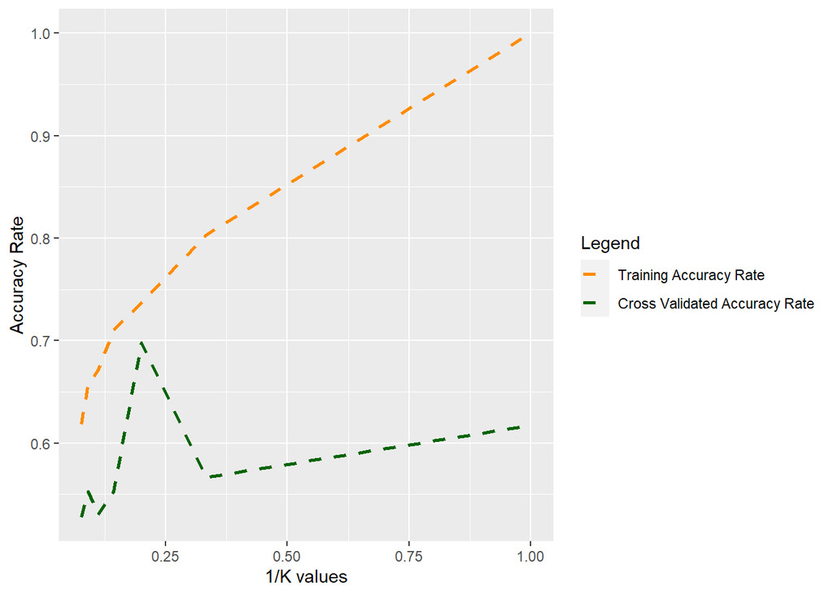

```r
plot_2 <- ggplot()+
  geom_line(data=plotting_data_frame,aes(y=accs_2_1,x= 1/knn_values,colour="Training Accuracy Rate"),size=1, linetype="dashed" )+
  geom_line(data=plotting_data_frame,aes(y=accs_2_2,x= 1/knn_values,colour="Cross Validated Accuracy Rate"),size=1, linetype="dashed") +
  scale_color_manual(name = "Legend", values = c("Training Accuracy Rate" = "darkorange", "Cross Validated Accuracy Rate"= "darkgreen")) + labs(y= "Accuracy Rate", x = "1/K values")

plot_2
```

# Section 3

```r
setwd("C:/Users/Asus/Desktop/AI Assignment")

source("./section3_code.r")
```

We first set the directory listing for CSV files:

```r
imagesDir<-"./Images"


imagesDir
```

```
## [1] "./Images"
```

Then we put all the features into a separate variable:

```r
allData <- read.table("./Images/all_features.csv")
allData
```

| V1 | V2 | V3 | V4 | V5 | V6 | V7 | V8 | V9 | V10 | V11 | V12 | V13 | V14 | V15 | V16 | V17 | V18 |
| --- | --- | --- | --- | --- | --- | --- | --- | --- | --- | --- | --- | --- | --- | --- | --- | --- | --- |
| a | 0 | 30 | 0 | 0 | 7 | 6 | 1.28571429 | 0 | 7 | 6 | 7 | 6 | 6 | 6 | 1 | 1 | 0 |
| a | 1 | 35 | 0 | 1 | 7 | 6 | 1.00000000 | 0 | 7 | 9 | 9 | 9 | 7 | 9 | 1 | 1 | 0 |
| a | 2 | 34 | 0 | 1 | 5 | 5 | 1.00000000 | 0 | 10 | 10 | 12 | 12 | 14 | 12 | 1 | 1 | 0 |
| a | 3 | 35 | 0 | 4 | 5 | 4 | 1.40000000 | 1 | 11 | 12 | 10 | 11 | 16 | 18 | 1 | 1 | 4 |
| a | 4 | 51 | 3 | 0 | 9 | 6 | 0.84615385 | 1 | 6 | 8 | 7 | 13 | 7 | 9 | 1 | 1 | 1 |
| a | 5 | 35 | 1 | 0 | 9 | 6 | 0.81818182 | 1 | 6 | 6 | 13 | 12 | 14 | 8 | 1 | 1 | 2 |
| a | 6 | 43 | 2 | 0 | 9 | 5 | 1.00000000 | 0 | 11 | 12 | 14 | 14 | 15 | 16 | 1 | 1 | 1 |
| a | 7 | 46 | 7 | 0 | 3 | 11 | 0.84615385 | 1 | 27 | 27 | 12 | 14 | 13 | 28 | 1 | 1 | 0 |
| a | 8 | 44 | 0 | 1 | 10 | 6 | 1.09090909 | 0 | 7 | 8 | 12 | 11 | 9 | 7 | 1 | 1 | 0 |
| a | 9 | 34 | 0 | 1 | 6 | 4 | 0.66666667 | 0 | 4 | 6 | 16 | 15 | 15 | 7 | 1 | 1 | 1 |

[output cut: 1290 more lines]

We then set the column names of the data:

```r
colnames(allData) <- c("label", "index", "nr_pix", "rows_with_1", "cols_with_1",
                       "rows_with_3p", "cols_with_3p", "aspect_ratio", "neigh_1",
                       "no_neigh_above", "no_neigh_below", "no_neigh_left", "no_neigh_right",
                       "no_neigh_horiz", "no_neigh_vert", "connected_areas", "eyes",
                       "custom")
```

We make ‘label’ as categorical factor as we’ll be classifying our data based on it. All the letters from ‘a’ to ‘j’ classified as letters, and others based on their emoticons.

```r
 levels = c("a", "b", "c", "d", "e", "f", "g", "h", "i", "j", "sad", "smiley", "xclaim")

 labels = c("letter","letter","letter","letter","letter","letter",
          "letter","letter","letter","letter", "sad", "smiley", "xclaim" )


allData$label <- factor(allData$label,
                        levels = levels, labels = labels)

str(allData)
```

```
## 'data.frame':    1300 obs. of  18 variables:
##  $ label          : Factor w/ 4 levels "letter","sad",..: 1 1 1 1 1 1 1 1 1 1 ...
##  $ index          : int  0 1 2 3 4 5 6 7 8 9 ...
##  $ nr_pix         : int  30 35 34 35 51 35 43 46 44 34 ...
##  $ rows_with_1    : int  0 0 0 0 3 1 2 7 0 0 ...
##  $ cols_with_1    : int  0 1 1 4 0 0 0 0 1 1 ...
##  $ rows_with_3p   : int  7 7 5 5 9 9 9 3 10 6 ...
##  $ cols_with_3p   : int  6 6 5 4 6 6 5 11 6 4 ...
##  $ aspect_ratio   : num  1.286 1 1 1.4 0.846 ...
##  $ neigh_1        : int  0 0 0 1 1 1 0 1 0 0 ...
##  $ no_neigh_above : int  7 7 10 11 6 6 11 27 7 4 ...
##  $ no_neigh_below : int  6 9 10 12 8 6 12 27 8 6 ...
##  $ no_neigh_left  : int  7 9 12 10 7 13 14 12 12 16 ...
##  $ no_neigh_right : int  6 9 12 11 13 12 14 14 11 15 ...
##  $ no_neigh_horiz : int  6 7 14 16 7 14 15 13 9 15 ...
##  $ no_neigh_vert  : int  6 9 12 18 9 8 16 28 7 7 ...
##  $ connected_areas: int  1 1 1 1 1 1 1 1 1 1 ...
##  $ eyes           : int  1 1 1 1 1 1 1 1 1 1 ...
##  $ custom         : int  0 0 0 4 1 2 1 0 0 1 ...
```

here, we choose 80 values of each of the 13 image types as training data and the rest as test data. Also, we have removed the custom feature as it was stated in the assignment specification.

```r
training_data <- allData[allData$index<80, 1:17]

test_data <- allData[allData$index >= 80, 1:17]
```

## Section 3.1

Here we will perform classification with random forests using 5-fold cross validation.

We first install the libraries needed and set seed:

```r
library(caret)
library(randomForest)
set.seed(42)
```

We first do the cross-validation. We perform a grid search of two hyper-parameters for our cross validation.

```r
train_control = trainControl(method="cv", number = 5, search = "grid", savePredictions = T)

set.seed(42)

tuningGrid <- expand.grid(mtry=c(2,4,6,8))
```

Now we will use random-forests with number of trees between 25 and 375 at increment of 50, and number of parameters individually at 2, 4, 6 and 8.

```r
set.seed(42)

# For number of trees = 25

model_25 = train(label~., data=training_data, method="rf", trControl = train_control,
              tuneGrid = tuningGrid, ntree = 25)

model_25
```

```
## Random Forest
##
## 1040 samples
##   16 predictor
##    4 classes: 'letter', 'sad', 'smiley', 'xclaim'
##
## No pre-processing
## Resampling: Cross-Validated (5 fold)
## Summary of sample sizes: 832, 832, 832, 832, 832
## Resampling results across tuning parameters:
##
##   mtry  Accuracy   Kappa
##   2     0.8836538  0.6929488
##   4     0.8846154  0.6973691
##   6     0.8875000  0.7052548
##   8     0.8730769  0.6702333
##
## Accuracy was used to select the optimal model using the largest value.
## The final value used for the model was mtry = 6.
```

```r
model_25$finalModel$ntree
```

```
## [1] 25
```

```r
# For number of trees = 75

model_75 = train(label~., data=training_data, method="rf", trControl = train_control,
              tuneGrid = tuningGrid, ntree = 75)

model_75
```

```
## Random Forest
##
## 1040 samples
##   16 predictor
##    4 classes: 'letter', 'sad', 'smiley', 'xclaim'
##
## No pre-processing
## Resampling: Cross-Validated (5 fold)
## Summary of sample sizes: 832, 832, 832, 832, 832
## Resampling results across tuning parameters:
##
##   mtry  Accuracy   Kappa
##   2     0.8769231  0.6761849
##   4     0.8826923  0.6931175
##   6     0.8750000  0.6762343
##   8     0.8711538  0.6660914
##
## Accuracy was used to select the optimal model using the largest value.
## The final value used for the model was mtry = 4.
```

```r
model_75$finalModel$ntree
```

```
## [1] 75
```

```r
# For number of trees = 125

model_125 = train(label~., data=training_data, method="rf", trControl = train_control,
              tuneGrid = tuningGrid, ntree = 125)

model_125
```

```
## Random Forest
##
## 1040 samples
##   16 predictor
##    4 classes: 'letter', 'sad', 'smiley', 'xclaim'
##
## No pre-processing
## Resampling: Cross-Validated (5 fold)
## Summary of sample sizes: 832, 832, 832, 832, 832
## Resampling results across tuning parameters:
##
##   mtry  Accuracy   Kappa
##   2     0.8865385  0.7005126
##   4     0.8750000  0.6703543
##   6     0.8769231  0.6791391
##   8     0.8759615  0.6773404
##
## Accuracy was used to select the optimal model using the largest value.
## The final value used for the model was mtry = 2.
```

```r
model_125$finalModel$ntree
```

```
## [1] 125
```

```r
# For number of trees = 175

model_175 = train(label~., data=training_data, method="rf", trControl = train_control,
              tuneGrid = tuningGrid, ntree = 175)

model_175
```

```
## Random Forest
##
## 1040 samples
##   16 predictor
##    4 classes: 'letter', 'sad', 'smiley', 'xclaim'
##
## No pre-processing
## Resampling: Cross-Validated (5 fold)
## Summary of sample sizes: 832, 832, 832, 832, 832
## Resampling results across tuning parameters:
##
##   mtry  Accuracy   Kappa
##   2     0.8769231  0.6697701
##   4     0.8759615  0.6749948
##   6     0.8730769  0.6698518
##   8     0.8701923  0.6593521
##
## Accuracy was used to select the optimal model using the largest value.
## The final value used for the model was mtry = 2.
```

```r
model_175$finalModel$ntree
```

```
## [1] 175
```

```r
# For number of trees = 225

model_225 = train(label~., data=training_data, method="rf", trControl = train_control,
              tuneGrid = tuningGrid, ntree = 225)

model_225
```

```
## Random Forest
##
## 1040 samples
##   16 predictor
##    4 classes: 'letter', 'sad', 'smiley', 'xclaim'
##
## No pre-processing
## Resampling: Cross-Validated (5 fold)
## Summary of sample sizes: 832, 832, 832, 832, 832
## Resampling results across tuning parameters:
##
##   mtry  Accuracy   Kappa
##   2     0.8855769  0.6952499
##   4     0.8807692  0.6899596
##   6     0.8778846  0.6862747
##   8     0.8798077  0.6886198
##
## Accuracy was used to select the optimal model using the largest value.
## The final value used for the model was mtry = 2.
```

```r
model_225$finalModel$ntree
```

```
## [1] 225
```

```r
# For number of trees = 275

model_275 = train(label~., data=training_data, method="rf", trControl = train_control,
              tuneGrid = tuningGrid, ntree = 275)

model_275
```

```
## Random Forest
##
## 1040 samples
##   16 predictor
##    4 classes: 'letter', 'sad', 'smiley', 'xclaim'
##
## No pre-processing
## Resampling: Cross-Validated (5 fold)
## Summary of sample sizes: 832, 832, 832, 832, 832
## Resampling results across tuning parameters:
##
##   mtry  Accuracy   Kappa
##   2     0.8817308  0.6847308
##   4     0.8817308  0.6862741
##   6     0.8769231  0.6787524
##   8     0.8807692  0.6877542
##
## Accuracy was used to select the optimal model using the largest value.
## The final value used for the model was mtry = 2.
```

```r
model_275$finalModel$ntree
```

```
## [1] 275
```

```r
# For number of trees = 325

model_325 = train(label~., data=training_data, method="rf", trControl = train_control,
              tuneGrid = tuningGrid, ntree =325)

model_325
```

```
## Random Forest
##
## 1040 samples
##   16 predictor
##    4 classes: 'letter', 'sad', 'smiley', 'xclaim'
##
## No pre-processing
## Resampling: Cross-Validated (5 fold)
## Summary of sample sizes: 832, 832, 832, 832, 832
## Resampling results across tuning parameters:
##
##   mtry  Accuracy   Kappa
##   2     0.8942308  0.7216262
##   4     0.8836538  0.6978879
##   6     0.8807692  0.6913834
##   8     0.8788462  0.6853691
##
## Accuracy was used to select the optimal model using the largest value.
## The final value used for the model was mtry = 2.
```

```r
model_325$finalModel$ntree
```

```
## [1] 325
```

```r
# For number of trees = 375

model_375 = train(label~., data=training_data, method="rf", trControl = train_control,
              tuneGrid = tuningGrid, ntree = 375)

model_375
```

```
## Random Forest
##
## 1040 samples
##   16 predictor
##    4 classes: 'letter', 'sad', 'smiley', 'xclaim'
##
## No pre-processing
## Resampling: Cross-Validated (5 fold)
## Summary of sample sizes: 832, 832, 832, 832, 832
## Resampling results across tuning parameters:
##
##   mtry  Accuracy   Kappa
##   2     0.8817308  0.6867935
##   4     0.8788462  0.6807145
##   6     0.8769231  0.6772713
##   8     0.8769231  0.6779904
##
## Accuracy was used to select the optimal model using the largest value.
## The final value used for the model was mtry = 2.
```

```r
model_375$finalModel$ntree
```

```
## [1] 375
```

Now the model with the highest accuracy is the second last model with number of trees = 325 and predictor number as 2. Hence it’s the best model.

```r
model_highest_accuracy = 0.8942308
```

We plot this model!

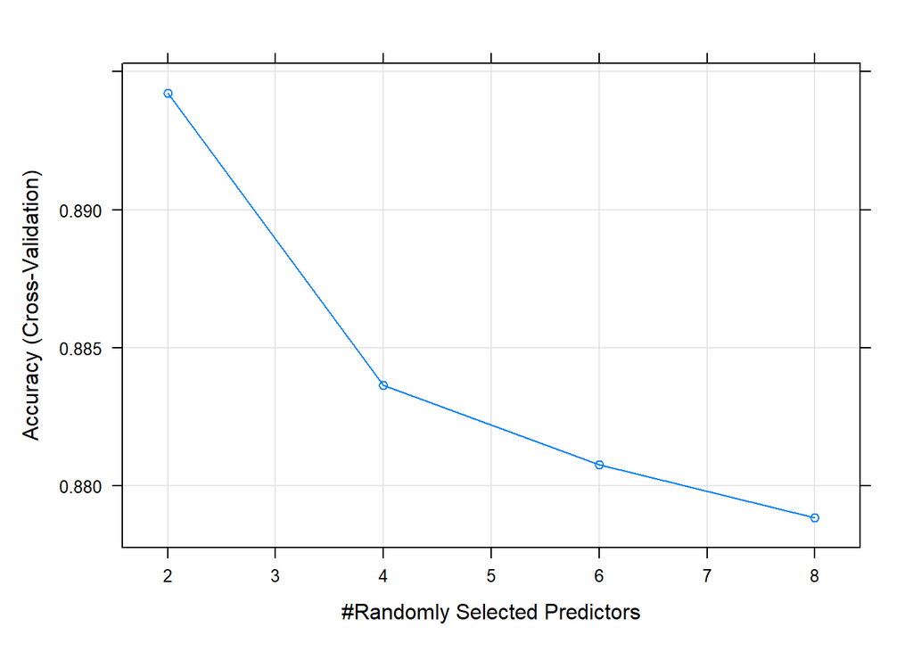

```r
plot.train(model_325)
```

From the graph, it’s visible that the random selected features we chose using cross-validation are 2, 4, 6 and 8.

The best predictor number is 2 for this model and apparently from the graph, the more number of predictor numbers we have, there’s a chance of more redundancy predictor numbers selected as split nodes. Hence that’s the reason for decrease of predictions.

## Section 3.2

In this section, we’ll use the best model from the previous section. The model with Nt = 325. We first set the cross-validation to 5-fold.

```r
train_control_refitted = trainControl(method="cv", number = 5, search = "grid", savePredictions = T)



tuningGrid_refitted <- expand.grid(mtry=c(2,4,6,8))
```

We then create a vector to store all the accuracies of the model in:

```r
all_accuracies <- c()

all_accuracies
```

Now, we refit the model 15 times. That means we run the same model 15 times and note the highest accuracy to the ‘all_accuracies’ vector.

```r
for (i in seq(1,15,1)) {

model_325 = train(label~., data=training_data, method="rf", trControl = train_control,
                  tuneGrid = tuningGrid, ntree = 325)

all_accuracies <- append(all_accuracies, max(model_325$results$Accuracy))


}
```

Then we print all the accuracies:

```r
print(all_accuracies)
```

```
##  [1] 0.8894231 0.8826923 0.8884615 0.8894231 0.8826923 0.8788462 0.8778846
##  [8] 0.8865385 0.8875000 0.8798077 0.8855769 0.8730769 0.8836538 0.8788462
## [15] 0.8903846
```

We get the mean of all accuracies:

```r
mean_of_accuracies <- mean(all_accuracies)
mean_of_accuracies
```

```
## [1] 0.8836538
```

We get the standard deviation of all accuracies:

```r
standard_deviation_of_accuracies <- sd(all_accuracies)
standard_deviation_of_accuracies
```

```
## [1] 0.005139639
```

Our standard deviation is significantly low. This means that we’re confident of our estimators of the model.

Now we check if our model performs better than chance.

We perform a one-sample t-test.

```r
t.test(all_accuracies)
```

```
##
##  One Sample t-test
##
## data:  all_accuracies
## t = 665.88, df = 14, p-value < 2.2e-16
## alternative hypothesis: true mean is not equal to 0
## 95 percent confidence interval:
##  0.8808076 0.8865001
## sample estimates:
## mean of x
## 0.8836538
```